# Principi di statistica e tools digitali

## 1b: Contenitori Python

### GG Analisi dei dati @ Fidia

**Speaker**: David Leoni info@davidleoni.it

Repository github per questi tutorial: https://github.com/DavidLeoni/ggad

Materiale tratto dal libro [SoftPython](https://it.softpython.org)

(Per navigare nelle slide premi Esc)

## Principali tipi di dati Python

| Tipo | Valore 'vuoto' | Esempio | Altro esempio | Mutabilità | Nota |
| --- | --- | --- | --- | --- | --- |
| `int` | `0` | `3` | `-5` | immutabili | possono essere arbitrariamente grandi |
| `float` | `0.0` | `3.7` | `-2.3` | immutabili | numeri in virgola mobile |
| `bool` | `False` | `True` |  | immutabili |  |
| `str` | `""` | `"Buon giorno"` | `'come stai?'` | immutabili |  |
| `tuple` | `()` | `(5, 7, 10, 7)` | `("qualcosa", 5, "altro ancora")` | immutabili |  |
| `list` | `[]` | `[5, 7, 10, 7]` | `["qualcosa", 5, "altro ancora"]` | mutabili |  |
| `set` | `set()` | `{7, 5, 10}` | `{"altro ancora", "qualcosa", 5}` | mutabili |  |
| `dict` | `{}` | `{'limoni':4, 'arance':7}` | `{'lampada':'illumina', 'termosifone':'scalda'}` | mutabili |  |
| `NoneType` | `None` |  |  |  |  |

**Riferimenti**: [SoftPython, Fondamenti - Tipi di dati](https://it.softpython.org/#data-types)

## Stringhe - str

Le stringhe sono sequenze *immutabili* di caratteri.

**Riferimenti** - SoftPython:

- [stringhe 1 - introduzione](https://it.softpython.org/strings/strings1-sol.html)
- [stringhe 2 - operatori](https://it.softpython.org/strings/strings2-sol.html)
- [stringhe 3 - metodi di base](https://it.softpython.org/strings/strings3-sol.html)
- [stringhe 4 - metodi di ricerca](https://it.softpython.org/strings/strings4-sol.html)

Python offre diversi operatori per lavorare con le stringhe:

| Operatore | Uso | Risultato | Significato |
| --- | --- | --- | --- |
| [len](https://it.softpython.org/strings/strings2-sol.html#Leggere-caratteri) | `len`(str) | int | Ritorna la lunghezza della stringa |
| concatenazione | str1 `+` str2 | str | Concatena due stringhe |
| [inclusione](https://it.softpython.org/strings/strings2-sol.html#Operatore-in) | str1 `in` str2 | bool | Controlla se la stringa è presente in un'altra stringa |
| [indice](https://it.softpython.org/strings/strings2-sol.html#Leggere-caratteri) | str`[`int`]` | str | Legge il carattere all'indice specificato |
| [slice](https://it.softpython.org/strings/strings2-sol.html#Slice) | str`[`int`:`int`]` | str | Estrae una sotto-stringa |
| uguaglianza | `==`,`!=` | `bool` | Controlla se due stringhe sono uguali o differenti |
| replicazione | str `*` int | str | Replica la stringa |

### Lunghezza

Per ottenere la lunghezza di una lista, possiamo usare la *funzione* `len`:

```python
len('legna')
```

```
5
```

### Leggere un carattere

Una stringa è una sequenza di caratteri

la posizione dei caratteri nella sequenza inizia da `0`

Come accedere al carattere in posizione `2`?

```python
#0123
'ciao'[2]
```

```
'a'
```

### Slice

Come leggere solo una sottosequenza che parte da un una posizione ad un'altra?

Basta indicare delle quadre `[` `]` con:

- indice di partenza *incluso*
- `:` come separatore
- indice di fine *escluso*

```python
         #0123456789
parola = 'mercantile'
```

```python
estratta = parola[3:8]
```

```python
estratta
```

```
'canti'
```

```python
parola
```

```
'mercantile'
```

**NOTA**: la stringa estratta è completamente NUOVA e slegata dall'originale:

```python
         #0123456789
parola = 'mercantile'

estratta = parola[3:8]
```

```python
parola = "peschereccio"
```

```python
print(estratta)
```

```
canti
```

### Concatenare stringhe

Una delle cose che si fanno più frequentemente è concatenare delle stringhe:

```python
"ciao " + "mondo"
```

```
'ciao mondo'
```

### Formattare stringhe

Attenzione a quando concateniamo una stringa e un numero

```
"ciao " + 7
```

Python si arrabbia:

```
---------------------------------------------------------------------------
TypeError                                 Traceback (most recent call last)
<ipython-input-38-e219e8205f7d> in <module>()
----> 1 "ciao " + 7

TypeError: Can't convert 'int' object to str implicitly
```

Bisogna convertire esplicitamente il numero (in genere, qualunque oggetto) in una stringa

Per concatenerare oggetti che non sono stringhe:

**Modo 1**: usare la funzione `str` come qui:

```python
"ciao " + str(7)
```

```
'ciao 7'
```

**Modo 2 (meglio)**: usare l'operatore di formattazione percentuale `%`

- sostituisce alle occorrenze di `%s` quello che mettete dopo un `%` dopo la stringa

```python
"ciao %s" % 7
```

```
'ciao 7'
```

`%s` può stare all'interno della stringa e venire ripetuto.

Per ogni occorrenza si può passare un sostituto diverso, come per esempio nella tupla `("bello", "Python")`

```python
"Che %s finalmente imparo %s" % ("bello", "Python")
```

```
'Che bello finalmente imparo Python'
```

### Formattare con le f-string

**Modo 3 (il migliore)** le *f-string* si costruiscono anteponendo `f` alla stringa e inserendo dentro la stringa delle graffe con le espressioni di cui vogliamo vedere il risultato.

```python
x = 3
y = 5
s = "Fantastico"

#  Nelle stringhe di formattazione possiamo mettere...
print( f"Metto variabili: {x} e anche espressioni: {x + y}. {s}!" )
```

```
Metto variabili: 3 e anche espressioni: 8. Fantastico!
```

### Riassegnare stringhe 1/2

Le stringhe sono immutabili...

...quindi tentare di sovrascrivere un carattere porta ad un errore:

```
#01234
s = 'ciao'

s[2] = 'b'  # SBAGLIATO!
```

```
---------------------------------------------------------------------------
TypeError                                 Traceback (most recent call last)
<ipython-input-113-e5847c6fa4bf> in <module>
----> 1 s[2] = 'b'

TypeError: 'str' object does not support item assignment
```

### Riassegnare stringhe 2/2

Quello che si può fare è cambiare *l'associazione* della variabile

Generiamo una nuova stringa prendendo pezzi dall'originale:

```python
s = 'ciao'
s = s[0] + s[1] + 'b' + s[3]
```

```python
s
```

```
'cibo'
```

Il vecchio oggetto `'ciao'` non essendo più raggiungibile da nessuna variabile, prima o poi verrà automaticamente marcato da Python come oggetto eliminabile dalla memoria tramite la cosiddetta *garbage collection*.

### Usare metodi degli oggetti

In Python quasi tutto è un oggetto

Ogni tipo di oggetto ha delle azioni chiamati *metodi* che si possono eseguire su quello oggetto

Per esempio, ogni stringa è un oggetto di tipo `str`

### Stringhe - Metodi base

| Metodo | Risultato | Significato |
| --- | --- | --- |
| [str.upper()](https://it.softpython.org/strings/strings3-sol.html#Esempio-upper) | str | Ritorna la stringa con tutti i caratteri maiuscoli |
| [str.lower()](https://it.softpython.org/strings/strings3-sol.html#Metodo-lower) | str | Ritorna la stringa con tutti i caratteri minuscoli |
| [str.capitalize()](https://it.softpython.org/strings/strings3-sol.html#Metodo-capitalize) | str | Ritorna la stringa con il primo carattere maiuscolo |
| [str1.startswith(str2)](https://it.softpython.org/strings/strings3-sol.html#Metodo-startswith) | bool | Controlla se la stringa inizia con un'altra |
| [str1.endswith(str2)](https://it.softpython.org/strings/strings3-sol.html#Metodo-endswith) | bool | Controlla se la stringa finisce con un'altra |
| [str1.isalpha(str2)](https://it.softpython.org/strings/strings3-sol.html#Metodo-isalpha) | bool | Controlla se tutti i caratteri sono alfabetici |
| [str1.isdigit(str2)](https://it.softpython.org/strings/strings3-sol.html#Metodo-isdigit) | bool | Controlla se tutti i caratteri sono cifre |
| [str.isupper()](https://it.softpython.org/strings/strings3-sol.html#Metodi-isupper-e-islower) | bool | Controlla se tutti i caratteri sono minuscoli |
| [str.islower()](https://it.softpython.org/strings/strings3-sol.html#Metodi-isupper-e-islower) | bool | Controlla se tutti i caratteri sono maiuscoli |

Riferimenti: [SoftPython - Stringhe 3](https://it.softpython.org/strings/strings3-sol.html)

Data una stringa che rappresenta un nome come `"trento"`...

quale metodo potremmo usare per rendere in maiuscolo la prima lettera?

Proviamo il metodo esistente `capitalize()`

(nota: la stringa è tutta in minuscolo e *capital* in inglese vuol anche dire 'maiuscolo' )

```python
"trento".capitalize()
```

```
'Trento'
```

### Stringhe - Metodi di ricerca

| Metodo | Risultato | Significato |
| --- | --- | --- |
| [str1.strip(str2)](https://it.softpython.org/strings/strings4-sol.html#Metodo-strip) | str | Rimuove stringhe dai lati |
| [str1.lstrip(str2)](https://it.softpython.org/strings/strings4-sol.html#Metodo-lstrip) | str | Rimuove stringhe da sinistra |
| [str1.rstrip(str2)](https://it.softpython.org/strings/strings4-sol.html#Metodo-rstrip) | str | Rimuove stringhe da destra |
| [str1.count(str2)](https://it.softpython.org/strings/strings4-sol.html#Metodo-count) | int | Conta il numero di occorrenze di una sottostringa |
| [str1.find(str2)](https://it.softpython.org/strings/strings4-sol.html#Metodo-find) | int | Ritorna la prima posizione di una sottostringa a partire da sinistra |
| [str1.rfind(str2)](https://it.softpython.org/strings/strings4-sol.html#Metodo-rfind) | int | Ritorna la prima posizione di una sottostringa a partire da destra |
| [str1.replace(str2, str3)](https://it.softpython.org/strings/strings4-sol.html#Metodo-replace) | str | Sostituisce sottostringhe |

Riferimenti: [SoftPython - Stringhe 4](https://it.softpython.org/strings/strings4-sol.html)

**ATTENZIONE: i metodi delle stringhe generano stringhe SEMPRE NUOVE**

L’oggetto stringa originale non viene MAI modificato.

### Esempio metodo stringhe: replace

```python
originale = "PARLARE E BRINDARE"

risultato = originale.replace('ARE', 'IAMO')
```

```python
risultato
```

```
'PARLIAMO E BRINDIAMO'
```

```python
originale
```

```
'PARLARE E BRINDARE'
```

## Liste - list

Una lista in python è una sequenza mutabile di elementi eterogenei, in cui possiamo mettere gli oggetti che vogliamo.

**Riferimenti - SoftPython:**

- [Liste 1 - introduzione](https://it.softpython.org/lists/lists1-sol.html)
- [Liste 2 - operatori](https://it.softpython.org/lists/lists2-sol.html)
- [Liste 3 - metodi base](https://it.softpython.org/lists/lists3-sol.html)
- [Liste 4 - metodi di ricerca](https://it.softpython.org/lists/lists4-sol.html)

Creiamo una lista di stringhe:

```python
lista = ["ciao", "soft", "python"]
```

```python
lista
```

```
['ciao', 'soft', 'python']
```

Le liste sono sequenze di oggetti possibilmente eterogenei...

quindi dentro ci potete buttare di tutto, interi, stringhe, duplicati, altre liste, ...:

```python
cose = ["ciao", 97, "ciao", ["a","b"] ]
```

```python
cose
```

```
['ciao', 97, 'ciao', ['a', 'b']]
```

### Liste - operatori

Per manipolare le liste vi sono diversi operatori. I seguenti si comportano come quelli visti per le stringhe.

| Operatore | Use | Risultato | Significato |
| --- | --- | --- | --- |
| len | `len`(lst) | `int` | Ritorna la lunghezza di una lista |
| indice | list`[`int`]` | obj | Legge/scrive un elemento all'indice specificato |
| slice | list`[`int`:`int`]` | `list` | Estrae una sotto-lista - ritorna una NUOVA lista |
| inclusione | obj `in` list | `bool` | Controlla se un elemento è presente in una lista |
| concatenazione | list `+` list | `list` | Concatena due liste - ritorna una NUOVA lista |
| aggregazione | `max`(lst) | `int` | Data una lista di numeri, ritorna il massimo |
| aggregazione | `min`(lst) | `int` | Data una lista di numeri, ritorna il minimo |
| aggregazione | `sum`(lst) | `int` | Data una lista di numeri, li somma tutti |
| replicazione | list `*` int | `list` | Replica la lista - ritorna una NUOVA lista |
| uguaglianza | `==`,`!=` | `bool` | Controlla se due liste sono uguali o differenti |

Riferimenti: [SoftPython - liste 2](https://it.softpython.org/lists/lists2-sol.html)

Per accedere ad un elemento usiamo un indice (come per per le stringhe):

```python
        #   0      1         2
lista = ["ciao", "soft", "python"]
lista[1]
```

```
'soft'
```

In una lista possiamo MODIFICARE le celle con l'assegnazione:

```python
lista[1] = "SOFT"
```

```python
lista
```

```
['ciao', 'SOFT', 'python']
```

### Liste - slice

Possiamo estrarre sottosequenze con le slice, come per le stringhe:

```python
#     0  1  2  3  4  5  6  7  8  9
la = [40,30,90,80,60,10,40,20,50,60]
lb = la[3:7]

print(lb)
```

```
[80, 60, 10, 40]
```

**ATTENZIONE**: l'estrazione produce una NUOVA lista

se modifichiamo l'originale non vedremo alcun cambiamento nella stringa estratta:

```python
la[3] = 999
```

```python
print(la)
```

```
[40, 30, 90, 999, 60, 10, 40, 20, 50, 60]
```

```python
print(lb)
```

```
[80, 60, 10, 40]
```

### Liste - Metodi di base

| Metodo | Ritorna | Descrizione |
| --- | --- | --- |
| [list.append(object)](https://it.softpython.org/lists/lists3-sol.html#Metodo-append) | `None` | Aggiunge un nuovo elemento alla fine della lista |
| [list.extend(list)](https://it.softpython.org/lists/lists3-sol.html#Metodo-extend) | `None` | Aggiunge diversi nuovi elementi alla fine della lista |
| [list.insert(int,object)](https://it.softpython.org/lists/lists3-sol.html#Metodo-insert) | `None` | Aggiunge un nuovo elemento a qualche posizione data |
| [list.pop()](https://it.softpython.org/lists/lists3-sol.html#Metodo-pop) | `object` | Rimuove e ritorna l'elemento all'ultima posizione |
| [list.pop(int)](https://it.softpython.org/lists/lists3-sol.html#Metodo-pop) | `object` | Dato un indice, rimuove e ritorna l'elemento a quella posizione |
| [list.reverse()](https://it.softpython.org/lists/lists3-sol.html#Metodo-reverse) | `None` | Inverte l'ordine degli elementi |
| [list.sort()](https://it.softpython.org/lists/lists3-sol.html#Metodo-sort) | `None` | Ordina gli elementi |
| ["sep".join(seq)](https://it.softpython.org/lists/lists3-sol.html#Metodo-join---da-liste-a-stringhe) | `str` | produce una stringa concatenando tutti gli elementi in seq separati da `"sep"` |

Riferimenti: [SoftPython - liste 3](https://it.softpython.org/lists/lists3-sol.html)

**I METODI DELLE LISTE *MODIFICANO* LA LISTA SU CUI VENGONO CHIAMATI !**

Quando chiami un metodo di una lista (l'oggetto a sinistra del punto `.`), MODIFICHI la lista stessa (diversamente dai metodi sulle stringhe che generano sempre una nuova stringa senza cambiare l'originale)

**ATTENZIONE: I METODI DELLE LISTE *NON* RITORNANO NULLA!**

Quasi sempre ritornano l'oggetto `None` (diversamente da quelli delle stringhe che ritornano sempre una nuova stringa)

### Liste: append

Possiamo aggiungere elementi alla fine di una lista usando il comando `append`:

```python
parole = []
```

```python
parole.append("ciao")
```

```python
parole
```

```
['ciao']
```

```python
parole.append("soft")
parole.append("python")
```

```python
parole
```

```
['ciao', 'soft', 'python']
```

### Esempio: ordinamento liste

Le liste si possono ordinare comodamente con il metodo `.sort`

- funziona su tutti gli oggetti ordinabili.

Proviamo i numeri:

```python
lista = [ 8, 2, 4]

lista.sort()
```

```python
lista
```

```
[2, 4, 8]
```

Proviamo ad ordinare delle stringhe:

```python
parole = [ 'mondo', 'python',  'ciao',]

parole.sort()
parole
```

```
['ciao', 'mondo', 'python']
```

Per generare una nuova lista invece di modificare l'originale, c'è `sorted()`

**NOTA**: `sorted` è una *funzione*, non un *metodo*:

```python
parole = [ 'mondo', 'python', 'ciao',]

sorted(parole)
```

```
['ciao', 'mondo', 'python']
```

```python
# la lista originale non è cambiata:
parole
```

```
['mondo', 'python', 'ciao']
```

**Ordine rovesciato**

Possiamo indicare *in fondo* il parametro opzionale `reverse` e il suo valore, che in questo caso sarà `True`:

```python
sorted(['mondo', 'python', 'ciao'], reverse=True)
```

```
['python', 'mondo', 'ciao']
```

**Rovesciare liste non ordinate**

Cercando nella libreria di Python,troviamo una comoda funzione `reversed()` che prende come paramatro la lista che vogliamo rovesciare e ne genera una nuova rovesciata:

```python
reversed([6,2,4])
```

```
<list_reverseiterator at 0x1bf5d678d90>
```

Problema: `reversed` produce una sequenza 'congelate', che va materializzata convertendola esplicitamente a lista così:

```python
list(  reversed([6,2,4]) )
```

```
[4, 2, 6]
```

### Liste - Metodi di ricerca

| Metodo | Ritorna | Descrizione |
| --- | --- | --- |
| [list.count(object)](https://it.softpython.org/lists/lists4-sol.html#Metodo-count) | `int` | Conta le occorrenze di un elemento |
| [list.index(object)](https://it.softpython.org/lists/lists4-sol.html#Metodo-index) | `int` | Trova la prima occorrenza di un elemento e ne ritorna la posizione |
| [list.remove(object)](https://it.softpython.org/lists/lists4-sol.html#Metodo-remove) | `None` | Rimuove la prima occorrenza di un elemento |
| [str1.split(str2)](https://it.softpython.org/lists/lists4-sol.html#Metodo-split---da-stringhe-a-liste) | `list` | Produce una lista con tutte le parole in str1 separate da str2 |

**ATTENZIONE**: spesso questi metodi vengono abusati portando a codice incorretto / inefficiente, usali con giudizio!

**Riferimenti:** [SoftPython - liste 4](https://it.softpython.org/lists/lists4-sol.html)

## Tuple - tuple

Una tupla in Python è una sequenza *immutabile* di elementi eterogenei che ammette duplicati

- perciò possiamo mettere gli oggetti che vogliamo
- ... di tipi diversi
- ... e ripetuti

Le tuple si creano con le parentesi tonde `()` e separando gli elementi da virgole `,`.

Qualche esempio:

```python
numeri = (6,7,5,7,7,9)
```

```python
print(numeri)
```

```
(6, 7, 5, 7, 7, 9)
```

```python
roba = (4, "carta", 5, 2,"scatole", 7)   # tupla eterogenea
```

**EVITA di mettere oggetti mutabili dentro le tuple!**

**Per creare una tupla di un solo elemento**: aggiungi una virgola dopo l'ultimo elemento:

```python
tuplina = (4,)  # occhio alla virgola !!!
```

```python
type(tuplina)
```

```
tuple
```

Per vedere la differenza, scriviamo qua sotto `(4)` senza virgola:

```python
farlocca = (4)
```

```python
type(farlocca)
```

```
int
```

Vediamo che `farlocca` è un `int`...

- il `4` è stato valutato come un'espressione dentro delle tonde e il risultato è il contenuto delle tonde!

### Tupla vuota

```python
vuota = ()
```

```python
print(vuota)
```

```
()
```

```python
type(vuota)
```

```
tuple
```

### Tuple senza parentesi

Per assegnare dei valori a delle variabili è possibile usare una notazione del genere,

in cui a sinistra dell' `=` mettiamo nomi di variabili e a destra una sequenza di valori:

```python
a,b,c = 1, 2, 3
```

```python
b
```

```
2
```

Se ci chiediamo cosa sia quel `1,2,3`, possiamo provare a mettere a sinistra solo una variabile:

```python
# ATTENZIONE: MEGLIO EVITARE !
x = 1,2,3
```

```python
type(x)
```

```
tuple
```

Vediamo che Python ha considerato quel `1,2,3` come una tupla.

**Attenzione: Se trovi strane tuple durante l'esecuzione, cerca virgole extra!**

```python
stringa_farlocca = "ciao",   # OCCHIO
```

```python
stringa_farlocca
```

```
('ciao',)
```

### Conversioni

Puoi creare una tupla da una qualsiasi sequenza, per esempio da una lista:

```python
tuple( [8,2,5] )
```

```
(8, 2, 5)
```

```python
list( (3,4,2,3)  )   # viceversa
```

```
[3, 4, 2, 3]
```

### Tuple - operatori

I seguenti operatori funzionano sulle tuple e si comportano esattamente come per le liste:

| Operatore | Risultato | Significato |
| --- | --- | --- |
| `len`(tuple) | `int` | Ritorna la lunghezza di una tupla |
| tuple`[`int`]` | `object` | Legge un elemento all'indice specificato |
| tuple`[`int`:`int`]` | `tuple` | Estrae una sotto-tupla - ritorna una NUOVA tupla |
| tuple1 `+` tuple2 | `tuple` | Concatena due tuple - ritorna una NUOVA tupla |
| object `in` tuple | `bool` | Controlla se un elemento è presente in una tupla |
| tuple `*` int | `tuple` | Replica la tupla - ritorna una NUOVA tupla |
| `==`,`!=` | `bool` | Controlla se due tuple sono uguali o differenti |

Riferimento: [SoftPython - Tuple](https://it.softpython.org/tuples/tuples1-sol.html#Operatori)

## Insiemi - set

**Riferimenti:** SoftPython, [insiemi](https://it.softpython.org/sets/sets1-sol.html)

Un insieme è una collezione *mutabile* *senza ordine* di elementi *immutabili* e *distinti* (cioè senza duplicati)

```python
s = {'b','a','d','c'}
```

```python
type(s)
```

```
set
```

```python
s = {'b','a','d','c'}
print(s)
```

```
{'d', 'c', 'b', 'a'}
```

**ATTENZIONE: L'ORDINE NEGLI INSIEMI** ***NON*** **E' GARANTITO!** ***NON*** **CREDERE A QUELLO CHE VEDI !!**

L'ordine in cui è stata effettuata la stampa è diverso da quello con cui abbiamo costruito l'insieme - potrebbe anche variare a seconda della versione di Python.

**Attenzione** a cosa succede se proviamo a chiedere a Jupyter di mostrarci il contenuto dell'insieme, scrivendo solo la variabile `s` SENZA la `print`:

```python
s
```

```
{'a', 'b', 'c', 'd'}
```

Adesso appare in ordine alfabetico !

Motivo: Jupyter per mostrare le variabili invece della print normale stampa implicitamente con la [pprint](https://docs.python.org/3/library/pprint.html) (*pretty* print), che SOLO per gli insiemi ci fa la cortesia di ordinare il risultato prima di stamparlo.

### Rimuovere duplicati

**Gli insiemi sono utili per rimuovere duplicati da una sequenza**

Come per liste e stringhe, possiamo creare un `set` a partire da un'altra sequenza:

```python
set('acacia') # da stringa
```

```
{'a', 'c', 'i'}
```

```python
set( [1,2,3,1,2,1,2,1,3,1] ) # da lista
```

```
{1, 2, 3}
```

**Indice degli elementi**: con gli insiemi NON è possibile ricavare un elemento a partire da un indice:

```
s[0]

---------------------------------------------------------------------------
TypeError                                 Traceback (most recent call last)
<ipython-input-352-c9c96910e542> in <module>
----> 1 s[0]

TypeError: 'set' object is not subscriptable
```

### Insieme vuoto

Per creare un insieme vuoto dobbiamo chiamare la funzione `set()`:

```python
s = set()
```

**ATTENZIONE: Se scrivi** `{}` **otterrai un dizionario, NON un insieme !!!**

### Operatori insiemi

| Operatore | Risultato | Descrizione |
| --- | --- | --- |
| `len`(set) | `int` | il numero di elementi nel set |
| el `in` set | `bool` | verifica se elemento è contenuto nel set |
| set `\|` set | `set` | unione, crea un NUOVO set |
| set `&` set | `set` | intersezione, crea un NUOVO set |
| set `-` set | `set` | differenza, crea un NUOVO set |
| set `^` set | `set` | differenza simmetrica, crea un NUOVO set |
| `==`,`!=` | `bool` | Controlla se due insiemi sono uguali o differenti |

Riferimento: [SoftPython - Insiemi](https://it.softpython.org/sets/sets1-sol.html#Operatori)

### Appartenenza

Per verificare se un elemento IMMUTABILE è contenuto in un insieme possiamo usare l'operatore `in` che ci ritorna un valore booleano:

```python
'a' in {'m','e','n','t','a'}
```

```
True
```

`in` **NEGLI INSIEMI E' UN'OPERAZIONE MOLTO VELOCE**

A differenza di liste e tuple, negli insiemi la velocità dell'operatore `in` NON dipende dalla dimensione della collezione

**ATTENZIONE**: Cercare elementi mutabili (es liste) in insiemi **non** è consentito:

```
['e','f'] in { ('c','d'), ('a','b')}

---------------------------------------------------------------------------
TypeError                                 Traceback (most recent call last)
/tmp/ipykernel_29295/1711245333.py in <module>
----> 1 ['a','b'] in { ('c','d'), ('a','b'), ('e','f') }

TypeError: unhashable type: 'list'
```

```python
('e','f') in { ('c','d'), ('a','b') }   # una tupla invece è immutabile quindi possiamo cercarla
```

```
False
```

Per verificare la **non appartenza**, ci sono due forme:

```python
"carota" not in {"anguria","banana","mela"}
```

```
True
```

```python
not "carota" in {"anguria", "banana", "mela"}
```

```
True
```

### Insiemi - metodi simili agli operatori

Vi sono metodi analoghi agli operatori `|`, `&`, `-`, `^` che creano un **NUOVO** set.

**NOTA**: diversamente dagli operatori, questi metodi accettano come parametro una *qualsiasi* sequenza, non solo insiemi:

| Metodo | Risultato | Descrizione | Operatore analogo |
| --- | --- | --- | --- |
| `set.union(seq)` | `set` | unione, crea un NUOVO set | `\|` |
| `set.intersection(seq)` | `set` | intersezione, crea un NUOVO set | `&` |
| `set.difference(seq)` | `set` | differenza, crea un NUOVO set | `-` |
| `set.symmetric_difference(seq)` | `set` | differenza simmetrica, crea un NUOVO set | `^` |

Metodi che **MODIFICANO** il primo insieme su cui sono chiamati (e ritornano `None`!):

| Metodo | Risultato | Descrizione |
| --- | --- | --- |
| `setA.update(setB)` | `None` | unione, MODIFICA `setA` |
| `setA.intersection_update(setB)` | `None` | intersezione, MODIFICA `setA` |
| `setA.difference_update(setB)` | `None` | differenza, MODIFICA `setA` |
| `setA.symmetric_difference_update(setB)` | `None` | differenza simmetrica, MODIFICA `setA` |

Riferimenti: [SoftPython - Insiemi](https://it.softpython.org/sets/sets1-sol.html#Metodi-simili-agli-operatori)

## Dizionari - dict

I dizionari sono dei contenitori mutabili che consentono di abbinare dei *valori* a delle voci dette *chiavi*.

**Riferimenti**:

- SoftPython - dizionari:
  1. [introduzione](https://it.softpython.org/dictionaries/dictionaries1-sol.html)
  2. [operatori](https://it.softpython.org/dictionaries/dictionaries2-sol.html)
  3. [metodi](https://it.softpython.org/dictionaries/dictionaries3-sol.html)

### Dizionari - operatori

| Operatore | Ritorna | Descrizione |
| --- | --- | --- |
| `len`(dict) | `int` | Ritorna il numero di chiavi |
| dict`[`chiave`]` | obj | Ritorna il valore associato alla chiave |
| dict`[`chiave`]` `=` valore |  | Aggiunge o modifica il valore associato ad una chiave |
| `del` dict`[`chiave`]` |  | Rimuove la coppia chiave/valore |
| chiave `in` dict | `bool` | Ritorna `True` se chiave è presente nel dizionario |
| `==`,`!=` | `bool` | Controlla se due dizionari sono uguali o differenti |

Riferimenti: [SoftPython - Dizionari 2](https://it.softpython.org/dictionaries/dictionaries2-sol.html)

Possiamo creare un dizionario con

- graffe esterne `{` `}`
- separando le chiavi dai valori con i due punti `:`
- separando le coppie chiave/valore con la virgola `,`

```python
d = { 'sedia'   : 'un mobile per sedersi',
      'armadio' : 'un mobile a ripiani',
}
```

Nota:

- spazi / ritorni a capo non contano
- l'ultima virgola è opzionale

### Leggere valori

Per accedere ai valori, possiamo usare le chiavi tra parentesi quadre:

```python
d = { 'sedia'   : 'un mobile per sedersi',
      'armadio' : 'un mobile a ripiani',
}


d['sedia']
```

```
'un mobile per sedersi'
```

```python
d['armadio']
```

```
'un mobile a ripiani'
```

### Modificare associazioni

Possiamo aggiungere un'associazione così:

```python
d['lampadario'] = 'un apparecchio di illuminazione'
```

```python
d
```

```
{'sedia': 'un mobile per sedersi',
 'armadio': 'un mobile a ripiani',
 'lampadario': 'un apparecchio di illuminazione'}
```

si può anche usare sovrascrivere le precedenti:

```python
d['armadio'] = 'un mobile a ripiani, solitamente due ante'
```

```python
d
```

```
{'sedia': 'un mobile per sedersi',
 'armadio': 'un mobile a ripiani, solitamente due ante',
 'lampadario': 'un apparecchio di illuminazione'}
```

### Dizionari - valori

Come valori nei dizionari possiamo mettere quello che ci pare, numeri, stringhe, tuple, liste, altri dizionari ..

```python
ingredienti = { 'farina' : 500,
                'uova' : 2,
                'zucchero' : 200,
}
```

```python
satelliti = {
    'Marte'    : ['Phobos','Deimos'],
    'Saturno'  : ['Titano','Hyperion', 'Mimas', 'Enceladus', 'Dione','Rhea'],
}
```

### Dizionari - chiavi

- possono essere **solo tipi** ***immutabili***, come per es. numeri, stringhe, tuple:
- non possono esserci chiavi duplicate

```python
d = {}

d[123] = 'ammissibile'
d['una stringa'] = 'ok'
d[ ('oppure','una','tupla') ] =  'va bene'
```

```python
d
```

```
{123: 'ammissibile',
 'una stringa': 'ok',
 ('oppure', 'una', 'tupla'): 'va bene'}
```

Cosa succede se tentiamo di usare tipi mutabili?

```
d[ ['io', 'sono', 'una', 'lista'] ] = "OCCHIO!"

TypeError                                 Traceback (most recent call last)
/tmp/ipykernel_3047/3187326270.py in <module>
----> 1 d[ ['io', 'sono', 'una', 'lista'] ] = "OCCHIO!"

TypeError: unhashable type: 'list'
```

## Dizionari - operatore in

Per sapere se una *chiave* è contenuta in un dizionario, possiamo usare l'operatore `in`.

**ATTENZIONE**: `in` nei dizionari cerca **solo** nelle chiavi!

```python
ingredienti = { 'farina'   : 500,
                'uova'     : 2,
                'zucchero' : 200,
}

'farina' in ingredienti
```

```
True
```

```python
500 in ingredienti
```

```
False
```

### Dizionari - Metodi

| Metodo | Ritorna | Descrizione |
| --- | --- | --- |
| [dict.keys()](https://it.softpython.org/dictionaries/dictionaries3-sol.html#keys) | `dict_keys` | Ritorna una *vista* di chiavi che sono presenti nel dizionario |
| [dict.values()](https://it.softpython.org/dictionaries/dictionaries3-sol.html#values) | `dict_values` | Ritorna una *vista* di valori presenti nel dizionario |
| [dict.items()](https://it.softpython.org/dictionaries/dictionaries3-sol.html#items) | `dict_items` | Ritorna una *vista* di coppie (chiave, valore) presenti nel dizionario |
| [d1.update(d2)](https://it.softpython.org/dictionaries/dictionaries3-sol.html#update) | `None` | MODIFICA il dizionario `diz1` con le coppie chiave / valore trovate in `diz2` |

**ATTENZIONE**: i metodi `keys`, `values` e `items` restituiscono *viste immutabili* e sono spesso causa di fraintendimenti e/o codice inefficiente. Se ti senti nella necessità di usarli, chiediti sempre se è possibile risolvere il problema usando solo gli operatori.

Riferimenti: [SoftPython - dizionari 3](https://it.softpython.org/dictionaries/dictionaries3-sol.html)

## Copy vs deep copy

Se vogliamo copiare una struttura dati mutabili, abbiamo a disposizione il metodo `.copy()`

- `.copy` effettua sulo una cosiddetta copia in superficie (*shallow copy*)
- per la copia in profondità (*deep copy*) servono altri sistemi!

### Esempio - lista di liste

```python
listonaA = [ ['Fate', 'attenzione'],
             ['a', 'dove'],
             ['puntano', 'le', 'frecce']
]
print(listonaA)
```

```
[['Fate', 'attenzione'], ['a', 'dove'], ['puntano', 'le', 'frecce']]
```

Proviamo a visualizzare il codice in [Python Tutor](https://pythontutor.com/visualize.html#mode=edit):

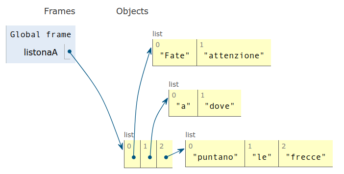

Proviamo adesso a fare una copia con il metodo `.copy()`:

```python
listonaA = [ ['Fate', 'attenzione'],
             ['a', 'dove'],
             ['puntano', 'le', 'frecce']
]
listonaB = listonaA.copy()  # copia *in superficie*
print(listonaA)
print(listonaB)
```

```
[['Fate', 'attenzione'], ['a', 'dove'], ['puntano', 'le', 'frecce']]
[['Fate', 'attenzione'], ['a', 'dove'], ['puntano', 'le', 'frecce']]
```

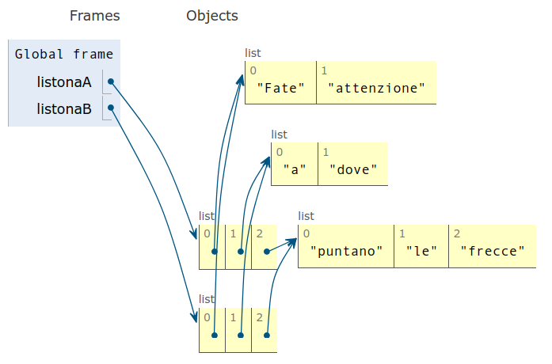

Notiamo che abbiamo due listone le cui celle puntano a delle sottoliste *condivise*, quindi scrivendo in una sotto cella di listonaA di fatto finiamo anche per scrivere in listonaB!

```python
listonaA = [ ['Fate', 'attenzione'],
             ['a', 'dove'],
             ['puntano', 'le', 'frecce']
]

listonaB = listonaA.copy()  # copia *in superficie*

listonaA[2][0]  = 'OCCHIO!' # cella con 'frecce'

print(listonaA)
print(listonaB)
```

```
[['Fate', 'attenzione'], ['a', 'dove'], ['OCCHIO!', 'le', 'frecce']]
[['Fate', 'attenzione'], ['a', 'dove'], ['OCCHIO!', 'le', 'frecce']]
```

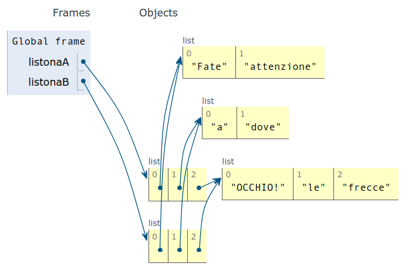

Per rimediare possiamo usare la cosidetta copia in profondità (*deep copy*) prima importando il modulo `copy` e poi chiamando la sua funzione `deepcopy` e passandogli come parametro `listonaA`:

```python
import copy   # MODULO PYTHON

listonaA = [ ['Fate', 'attenzione'],
             ['a', 'dove'],
             ['puntano', 'le', 'frecce']
]

listonaB = copy.deepcopy(listonaA)

listonaA[2][0]  = 'OCCHIO!' # cella con 'frecce'

print(listonaA)
print(listonaB)
```

```
[['Fate', 'attenzione'], ['a', 'dove'], ['OCCHIO!', 'le', 'frecce']]
[['Fate', 'attenzione'], ['a', 'dove'], ['puntano', 'le', 'frecce']]
```

Con `copy.deepcopy` abbiamo veramente strutture dati completamente distinte:

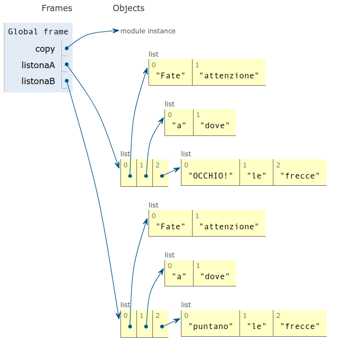

## CHALLENGE - Censura al tiramisù

✪ Ci è stato inviato un testo illegale, immorale e che fa pure ingrassare. Per tutelare la pubblica salute abbiamo l'arduo compito di censurarlo e renderlo consono al buon costume.

1. E' necessario sostituire OGNI occorrenza di due `parole_malefiche` con una più salubre censura, trasformando il testo in modo che la `print` di `testo_censurato` non contenga nessuna parola incriminata.

Esempio:

```
testo= "Grazie all'uso di Cera Splendent tutto brilla!"
parola_malefica = "splendent"
censura = "******"
testo_censurato: "Grazie all'uso di Cera ****** tutto brilla!"
```

2. Per scrivere il nostro rapporto di censori dobbiamo rendere conto di quante parole abbiamo censurato. Stampare alla fine il numero (ovviamente in maniera automatica ), per esempio:

```
"Censurata 1 parola"
```

**Continua alla prossima slide**

```python
testo = """Ed è proprio da questa portentosa crema che nasce la crema
al mascarpone base del tiramisù, prima classificata al premio Crema
dell'Anno insieme alla nutella. Il dolce italiano per eccellenza,
quello più famoso e amato, ma soprattutto che ha dato vita a
tantissime altre versioni, anche tiramisù senza uova! Poi il Tiramisù
alle fragole o quello alla Nutella, giusto per citarne un paio!
Senza contare le rivisitazioni più raffinate come la crostata morbida
o la torta al tiramisù.
"""

parola_malefica1 = "Tiramisù"
parola_malefica2 = "nutella"

censura = "******"

testo_censurato = ''

# scrivi qui
```

## CHALLENGE - Cantina

✪✪ Requisiti: [liste](https://it.softpython.org/lists/lists1-sol.html)

Data una stringa `parola`, creare una NUOVA lista che contenga la parola seguita da sè stessa rovesciata

- **NOTA**: l'ultima lettera NON deve essere duplicata

Esempio - dato:

```
parola = "cantina"
```

deve stampare:

```
['c', 'a', 'n', 't', 'i', 'n', 'a', 'n', 'i', 't', 'n', 'a', 'c']
```

```python
parola = "cantina" #['c','a','n','t','i','n','a','n','i','t','n','a','c']
#parola = "vino"   # ['v', 'i', 'n', 'o', 'n', 'i', 'v']
#parola = "ok"     # ['o', 'k', 'o']

# scrivi qui
```

## CHALLENGE - cannocchiale

✪ Requisiti: [tuple](https://it.softpython.org/tuples/tuples1-sol.html), [stringhe](https://it.softpython.org/strings/strings1-sol.html), [liste](https://it.softpython.org/lists/lists1-sol.html)

Data una stringa `s`, scrivi del codice che mette in una variabile tupla `ordinata` tutti i caratteri di `s` ordinati

Esempio - data:

```
s = "cannocchiale"
```

Dopo il tuo codice deve risultare:

```
>>> print(ordinata)
('a', 'a', 'c', 'c', 'c', 'e', 'h', 'i', 'l', 'n', 'n', 'o')
```

```python
s = "cannocchiale"

# scrivi qui
```

## CHALLENGE - Nozze di platino

✪ Requisiti: [dizionari](https://it.softpython.org/dictionaries/dictionaries1-sol.html)

Al tranquillissimo paesino di Gerontonia vi sono delle coppie assai tenaci che dopo 75 anni dal fatico "Sì!" meritano di festeggiare le nozze di platino. Abbiamo una lista dei matrimoni con esattamente 3 coppie scritte nel formato "maschio-femmina", e vogliamo creare un dizionario `diz` che associa ad ogni maschio la corrispondente compagna.

Assumi che i nomi dei maschi siano tutti diversi e che vi siano **esattamente** 3 coppie

Esempio - data:

```
matrimoni = ["Amilcare-Maria Eusonia", "Oronzo Pio-Genoveffa", "Venceslao-Elvira"]
```

dopo il tuo codice, deve risultare:

```
>>> print(diz)
{'Amilcare'   : 'Maria Eusonia',
 'Oronzo Pio' : 'Genoveffa',
 'Venceslao'  : 'Elvira'}
```

```python
matrimoni = ["Amilcare-Maria Eusonia", "Oronzo Pio-Genoveffa", "Venceslao-Elvira"]
#matrimoni = ["Liutprando-Brunilde", "Clodoveo-Elvira Pancrazia Ludmilla", "Gian Evaristo-Ubalda"]

# scrivi qui
```

## CHALLENGE - I pescatori

✪ Requisiti: [dizionari](https://it.softpython.org/dictionaries/dictionaries1-sol.html)

Una compagnia di pescatori ogni giorno cattura dei `pesci` che poi rivende a vari ristoranti. Ogni ristorante richiede diversi specie di pesci. Dati un `ristorante` e dei `pesci`, scrivi del codice che stampa `True` se il ristorante cucina quei pesci, altrimenti stampa `False`.

- **NON** usare `if`
- **NON** usare cicli
- **SUGGERIMENTO**: se non sai come fare, guarda [Booleani - Ordine di valutazione](https://it.softpython.org/basics/basics2-bools-sol.html#Ordine-di-valutazione)

**Continua alla prossima slide...**

```python
ristorante, pesci = "Il Galeone", "carpe"            # True
#ristorante, pesci = "Il Galeone", "aringhe"         # False
#ristorante, pesci = "Al Molo",    "trote"           # True
#ristorante, pesci = "Al Molo",    "orate"           # False
#ristorante, pesci = "La Cambusa", "merluzzi"        # False


registro = {
    "L'Ancora"  : ['aringhe', 'carpe'],
    "Il Galeone": ['merluzzi', 'carpe', 'trote'],
    "Al Molo"   : ['trote'],
    "La Cambusa": ['aringhe', 'carpe'],
}

# scrivi qui
```

## CHALLENGE - Festone di laurea

✪ Requisiti: [insiemi](https://it.softpython.org/sets/sets1-sol.html)

Evviva! Ci siamo laureati! E per coincidenza ci siamo riusciti nella stessa sessione dei nostri grandi amici Gianni e Giulia. Ora naturalmente stiamo cercando di organizzare una festa e ci piacerebbe farla tutti insieme.

Purtroppo però a causa delle norme Covid non possiamo fare assembramento e sono perciò vietate i raduni con più di **13** persone.

Siccome ora siamo dottori, l'idea è quella di risolvere il problema con un bel programmino Python. Abbiamo tre liste di invitati e siccome noi festeggiati siamo tutti amici ci sono ovviamente persone che verrebbero invitate più volte.

1. Trova il numero di invitati effettivi (le persone che verranno alla festa)
2. Stampa la lista di nomi SENZA duplicati
3. Trova il numero delle persone che hanno ricevuto **almeno** 2 inviti
4. Trova l'elenco delle persone che hanno ricevuto **almeno** 2 inviti

**Continua alla prossima slide..**

Esempio - dati:

```
invitati_miei =   ["VittorioG", "LucaB", "DavidL", "GiorgioC", "MichelaF", "GiuliaA", "VittorioG", ]
invitati_gianni = ["SamanthaV", "LucaB", "GiorgioC", "MichelaF", "MartaB", "EmmaK"]
invitati_giulia = ["DavidL", "GiorgioC", "MichelaF", "MassimilianoL", "VittorioG", "RobertoU", "EmmaK"]
```

dopo il tuo codice, deve stampare:

```
Invitati miei:  6
Invitati gianni:  6
Invitati giulia:  7
Numero invitati:  11
Nomi invitati:  {'MassimilianoL', 'MartaB', 'MichelaF', 'EmmaK', 'GiorgioC', 'DavidL', 'VittorioG', 'SamanthaV', 'RobertoU', 'LucaB', 'GiuliaA'}
Numero amici invitati almeno 2 volte: 6
Amici invitati almeno due volte:  {'GiorgioC', 'DavidL', 'MichelaF', 'VittorioG', 'LucaB', 'EmmaK'}
```

**Continua alla prossima slide..**

```python
# Input (NON modificare)

invitati_miei =   ["VittorioG", "LucaB", "DavidL", "GiorgioC", "MichelaF", "GiuliaA", "VittorioG", ]
invitati_gianni = ["SamanthaV", "LucaB", "GiorgioC", "MichelaF", "MartaB", "EmmaK"]
invitati_giulia = ["DavidL", "GiorgioC", "MichelaF", "MassimilianoL", "VittorioG", "RobertoU", "EmmaK"]

# scrivi qui
```